# HUDM5124AssignmentHC

Zhuqian Zhou

2017/4/3

# 1

**Using the compiled (mean) Olympic winter sports proximity ratings, apply a hierarchical clustering method, and draw the resulting dendrogram. You have several options:** **a. do single-link clustering, by hand** **b. do average-link clustering (by hand, SPSS, or R)** **In one or two sentences, interpret the resulting dendrogram (tree).**

I choose to do clustering by R.

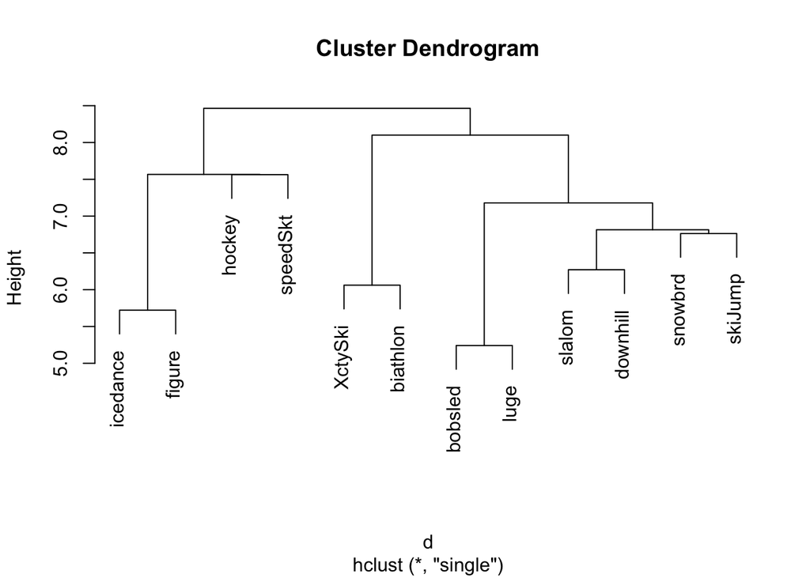

```r
x <- read.table("olympic data mean dissim.txt") # read in the data
d <- dist(x, method = "euclidean") # for "hclust" package, first create a distance matrix from multivariate data
sl <- hclust(d, method="single") # do single-link clustering
plot(sl) # display dendogram for single-link
```

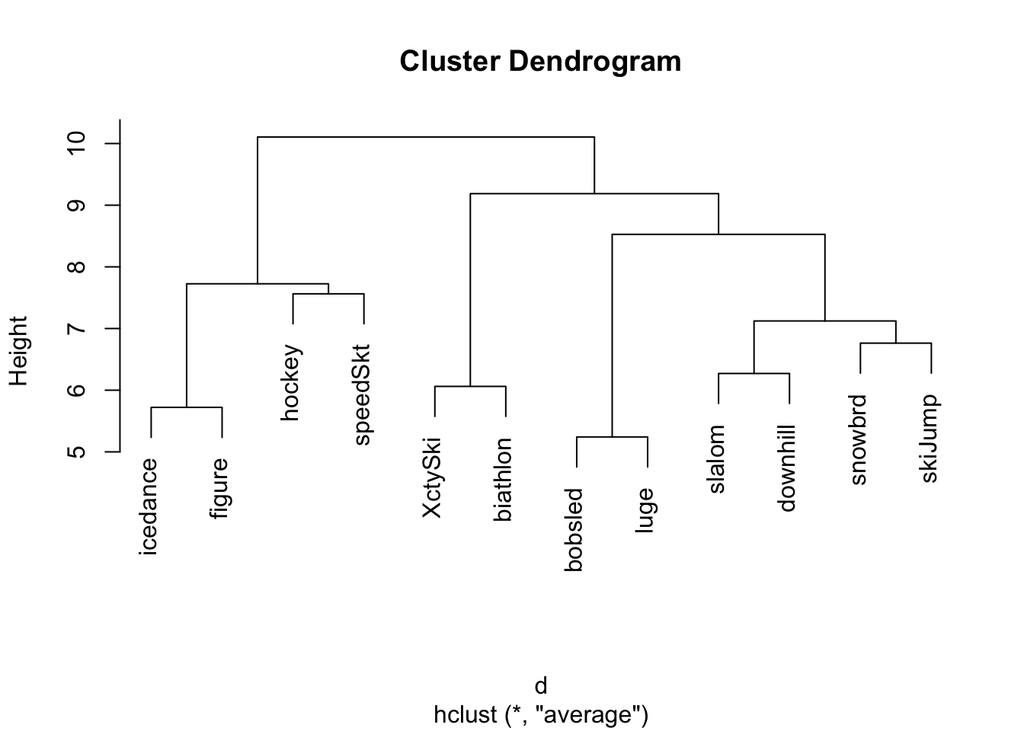

```r
al <- hclust(d, method="average") # do average-link clustering
plot(al) # display dendogram for average-link
```

Though the height of the tree of SL is smaller than that of the tree of AL, the two dendrograms have the same clusters for Olympic winter sports. At the bottom layer, 12 sports were clustered in to 6 pairs, i.e. art-related (icedance, figure), speed-on-ice (hockey, speedSkt), long-distance skiing (XctySki, biathlon), sledge-related skiing (bobsled, luge), high-speed-on-snow (slalom, downhill), skillful skiing (snowbrd, skiJump). Then, 4 of the 6 pairs were clustered into 2 groups, i.e. on ice (art-related, speed-on-ice) and high-risk skiing (speed-on-snow, skillful skiing). Futher, sledge-related skiing (bobsled, luge) and high-risk skiing (high-speed-on-snow, skillful skiing) were clusterd together as speed-on-snow (sledge-related skiing, high-risk skiing) which continued to be clustered with long-distance skiing (XctySki, biathlon) as a larger cluster, on snow (long-distance skiing, speed-on-snow). Finally, on ice (art-related, speed-on-ice) and on snow (long-distance skiing, speed-on-snow) were clustered into one set, i.e. winter sports.

# 2

**Using the posted data set on crimes for a sample of American cities (from Hartigan, 1975), apply Ward’s method (using SPSS CLUSTER or R) to obtain a hierarchical clustering of the cities.** **In one or two sentences, interpret the resulting dendrogram (tree).**

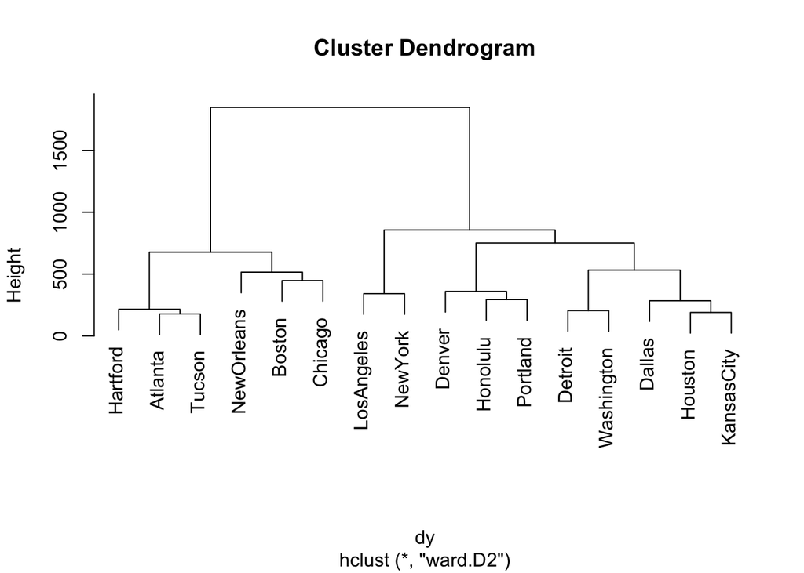

```r
y <- read.table("Crimes_Hartigan_1975.txt", sep = " ", header = TRUE)
rownames(y) <- y[,1]
y <- y[,-1]
dy <- dist(y, method = "euclidean")
W.D2 <- hclust(dy, method="ward.D2")
plot(W.D2)
```

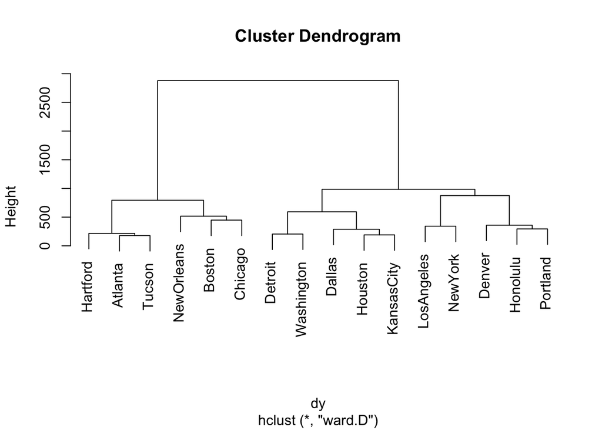

```r
W.D <- hclust(dy, method="ward.D")
plot(W.D)
```